# A novel role for alkyladenine DNA glycosylase in regulating alkylation-induced ER stress

Figure S2

L Milano, CF Charlier, R Andreguetti, T Cox, E Healing, MP Thomé, RM Elliott, JY Masson, LD Samson, JY Masson, G Lenz, JAP Henriques, A Nohturfft and LB Meira

*Introduction:*  
Gene-set enrichment analysis showed that genes induced by MMS in wild-type liver are enriched for many genesets induced by drug treatments. Many of these drugs are known to induce ER stress!

The finding supports the conclusion that MMS induces ER stress in mouse liver.

*Objective:*  
Plot a clustered binary heatmap of genes induced by MMS (this study) and by other drugs known to induce ER stress.

*Note*: This analysis requires input data generated by an earlier script.

## Setup

- Clear memory and console
- Load packages
- Get current script name

```r
# Clear memory
rm(list=setdiff(ls(all=TRUE), c(".Random.seed")))
# Clear console
cat("\014")
```

```r
this.script <- rstudioapi::getActiveDocumentContext()$path %>% basename
cat(cat("Script:", this.script))
```

```
Script: 09_Figure_S2.Rmd
```

## Analyse enrichment results for genes induced by MMS in wild-type liver

### Load enrichment data

```r
# list.files()
enriched.xlsx.file <- "Supplemental_Data_2.xlsx"
the.sheet <- "wt.mms.vs.wt.ctrl_up"
stopifnot(file.exists(enriched.xlsx.file))
enriched.wt.up <- openxlsx::read.xlsx(xlsxFile = enriched.xlsx.file,
                                      sheet=the.sheet, colNames = TRUE, startRow = 5)
cat("File read: ", enriched.xlsx.file, " (Worksheet '", "wt.mms.vs.wt.ctrl_up", "')", sep="")
```

```
File read: Supplemental_Data_2.xlsx (Worksheet 'wt.mms.vs.wt.ctrl_up')
```

```r
rm(enriched.xlsx.file)
```

### Select enriched library terms related to drug regulation

```r
drug.libs <- grep("drug", enriched.wt.up$Library, ignore.case=TRUE, value=TRUE) %>% unique %>% sort
cat("**Matching enrichr libraries:**  \n\n", paste0("* ", drug.libs, "  \n"), sep="")
```

**Matching enrichr libraries:**

- Drug_Perturbations_from_GEO_2014
- Drug_Perturbations_from_GEO_down
- Drug_Perturbations_from_GEO_up
- RNA-Seq_Disease_Gene_and_Drug_Signatures_from_GEO

### Filter on terms related to up regulation by drugs

```r
drug.libs.up.df <- enriched.wt.up %>%
  filter(Library %in% drug.libs) %>%
  filter(grepl("up$", Library, ignore.case=T) | grepl("up$", Term, ignore.case=T))
cat("Number of matching library terms:", nrow(drug.libs.up.df))
```

```
Number of matching library terms: 57
```

```r
DT::datatable(drug.libs.up.df[,1:2], caption="Terms related to upregulation by drugs", options=list(pageLength=5))
```

|  | Library | Term |
| --- | --- | --- |
| 1 | Drug_Perturbations_from_GEO_up | acetaminophen DB00316 mouse GSE37874 sample 2482 |
| 2 | Drug_Perturbations_from_GEO_up | CONCANAVALIN A 596316 mouse GSE17184 sample 3367 |
| 3 | Drug_Perturbations_from_GEO_up | gamma-Tocotrienol 5282349 human GSE21946 sample 3242 |
| 4 | Drug_Perturbations_from_GEO_up | CONCANAVALIN A 596316 mouse GSE17184 sample 3366 |
| 5 | Drug_Perturbations_from_GEO_up | Bisphenol A 6623 human GSE17624 sample 2659 |
| 6 | Drug_Perturbations_from_GEO_up | PBDE 47 95170 human GSE8588 sample 3050 |
| 7 | Drug_Perturbations_from_GEO_up | Bisphenol A 6623 human GSE17624 sample 2663 |
| 8 | Drug_Perturbations_from_GEO_up | Monuron 8800 rat GSE51163 sample 2467 |
| 9 | RNA-Seq_Disease_Gene_and_Drug_Signatures_from_GEO | Bmal1 Liver Knockout ZT4 GSE70497 up |
| 10 | Drug_Perturbations_from_GEO_2014 | ursodeoxycholic acid mus musculus gpl6246 gse22608 chdir up |

[output cut: 47 more lines]

## Drugs known to induce ER stress

### Select ER-stress-inducing drugs

```r
er.stress.inducers <- c("Acetaminophen", "Bisphenol A", "Cadmium", "Carboplatin",
                        "PBDE 47", "PBDE 85", "Palmitic acid", "Progesterone",
                        "Tocotrienol", "Ursodeoxycholic acid"
)
```

```r
# er.stress.inducers <- c("Acetaminophen", "Arsenite", "Azacitidine", "Bisphenol A",
#                         "Cadmium", "Carbon Tetrachloride", "Carboplatin", "Chlorhexidine",
#                         "Colchicine", "Dexamethasone", "Geldanamycin", "Ionomycin",
#                         "MLN4924", "Niclosamide", "PBDE 47", "PBDE 85", "Palmitic acid",
#                         "Progesterone", "Spiperone", "Sulindac", "Tanespimycin",
#                         "Thioridazine", "Tocotrienol", "Ursodeoxycholic acid")
```

A literature study was performed on the drugs listed in the 57 enrichr library terms above. This search identified 10 drugs from the list that are known to induce ER stress:

```r
cat("**ER stress inducers:**  \n\n",
    paste0("* ", er.stress.inducers, "  \n"), sep="")
```

**ER stress inducers:**

- Acetaminophen
- Bisphenol A
- Cadmium
- Carboplatin
- PBDE 47
- PBDE 85
- Palmitic acid
- Progesterone
- Tocotrienol
- Ursodeoxycholic acid

### Filter enrichment data on library terms related to ER stress-inducing drugs

```r
# Check that all drugs are covered in the 'Term' column:
x <- sapply(er.stress.inducers, function(x) {
  any(grepl(x, drug.libs.up.df$Term, ignore.case=T))
})
# sum(x)
# dput(er.stress.inducers[x])
stopifnot(all(x))
rm(x)
```

```r
# Generate a search string to be used with grep below:
search.str <- paste(er.stress.inducers, collapse="|")
# Subsetting:
drug.libs.up.stress.df <- drug.libs.up.df %>%
  dplyr::filter(grepl(search.str, Term, ignore.case=T))
rm(search.str)
cat("Number of library terms selected:", nrow(drug.libs.up.stress.df))
```

```
Number of library terms selected: 14
```

```r
drug.libs.up.stress.df %>%
  dplyr::select(Library, Term, Adj.P.val) %>%
  dplyr::arrange(Adj.P.val) %>%
  dplyr::mutate(Adj.P.val = signif(Adj.P.val, digits=3)) %>%
  DT::datatable(., options = list(pageLength=5))
```

|  | Library | Term | Adj.P.val |
| --- | --- | --- | --- |
| 1 | Drug_Perturbations_from_GEO_up | acetaminophen DB00316 mouse GSE37874 sample 2482 | 2.46e-26 |
| 2 | Drug_Perturbations_from_GEO_up | gamma-Tocotrienol 5282349 human GSE21946 sample 3242 | 4.96e-15 |
| 3 | Drug_Perturbations_from_GEO_up | Bisphenol A 6623 human GSE17624 sample 2659 | 2.37e-12 |
| 4 | Drug_Perturbations_from_GEO_up | PBDE 47 95170 human GSE8588 sample 3050 | 2.64e-11 |
| 5 | Drug_Perturbations_from_GEO_up | Bisphenol A 6623 human GSE17624 sample 2663 | 3.59e-11 |
| 6 | Drug_Perturbations_from_GEO_2014 | ursodeoxycholic acid mus musculus gpl6246 gse22608 chdir up | 3.52e-10 |
| 7 | Drug_Perturbations_from_GEO_up | PBDE 85 177368 human GSE8588 sample 3051 | 1.12e-09 |
| 8 | Drug_Perturbations_from_GEO_up | acetaminophen DB00316 mouse GSE37874 sample 3301 | 1.62e-09 |
| 9 | Drug_Perturbations_from_GEO_up | progesterone 5994 mouse GSE6440 sample 3686 | 8.95e-09 |
| 10 | Drug_Perturbations_from_GEO_up | CADMIUM 23973 human GSE9951 sample 3403 | 1.32e-08 |

[output cut: 4 more lines]

Generate a list object that stores overexpressed genes for each of the ER stress inducing drugs:

```r
er.stress.inducers
```

```
 [1] "Acetaminophen"        "Bisphenol A"          "Cadmium"              "Carboplatin"
 [5] "PBDE 47"              "PBDE 85"              "Palmitic acid"        "Progesterone"
 [9] "Tocotrienol"          "Ursodeoxycholic acid"
```

```r
get.short.title <- function(x) {
  y <- gsub("Bisphenol A", "Bisphenol_A", x, ignore.case = T)
  y <- gsub("gamma-Tocotrienol", "Tocotrienol", y, ignore.case = T)
  y <- gsub("PBDE 47", "PBDE_47", y, ignore.case = T)
  y <- gsub("PBDE 85", "PBDE_85", y, ignore.case = T)
  y <- gsub("ursodeoxycholic acid", "Ursodeoxycholate", y, ignore.case = T)
  y <- gsub("palmitic acid", "Palmitate", y, ignore.case = T)
  y <- gsub("CADMIUM", "Cadmium", y, ignore.case = T)
  z <- strsplit(y, split="[ -]")[[1]][1]
  Hmisc::capitalize(z)
}
```

```r
# names(drug.libs.up.stress.df)
drugs.gene.list <- lapply(seq_len(nrow(drug.libs.up.stress.df)), function(i, er.stress.inducers) {
  # i <- 1
  lib.term <- unlist(drug.libs.up.stress.df$Term[i])
  # gene.set
  lib.term.short <- get.short.title(lib.term)
  # gene.set.short
  list(
    Term = lib.term,
    Term.short = lib.term.short,
    Genes = strsplit(drug.libs.up.stress.df$Genes[i], split=",")[[1]]
  )
}, er.stress.inducers=er.stress.inducers)
```

```r
x <- paste(utils::capture.output(str(drugs.gene.list)), collapse="<br>\n", sep="")
details::details(x, summary="Show summary of gene list object", lang=NULL)
```

**Show summary of gene list object**

List of 14  
$ :List of 3  
..$ Term : chr “acetaminophen DB00316 mouse GSE37874 sample 2482”  
..$ Term.short: chr “Acetaminophen”  
..$ Genes : chr “TRABD;LRRC59;FICD;RGS16;MIS12;TXNDC11;UAP1;CXCL1;ORM2;ICAM1;HERPUD1;UNG;CKS1B;NARS;GMPPB;SOCS3;TMED3;PELO;TMED5”| **truncated**  
$ :List of 3  
..$ Term : chr “gamma-Tocotrienol 5282349 human GSE21946 sample 3242”  
..$ Term.short: chr “Tocotrienol”  
..$ Genes : chr “FKBP11;TES;FICD;GOLT1B;UAP1;HERPUD1;LMAN1;CREB3L2;EIF4EBP1;WARS;HSPA5;GFPT1;ENTPD7;GOLPH3L;NR1D2;ARFGAP3;SLC39A”| **truncated**  
$ :List of 3  
..$ Term : chr “Bisphenol A 6623 human GSE17624 sample 2659”  
..$ Term.short: chr “Bisphenol_A”  
..$ Genes : chr “TES;GOLT1B;UAP1;HERPUD1;NARS;TAF1D;EIF4EBP1;ARFIP2;MLEC;ANXA7;SNHG1;WARS;HSPA5;GFPT1;MANF;GNL3;ARCN1;INHBE;CDK7”| **truncated**  
$ :List of 3  
..$ Term : chr “PBDE 47 95170 human GSE8588 sample 3050”  
..$ Term.short: chr “PBDE_47”  
..$ Genes : chr “FKBP11;SNHG1;WARS;FICD;SSR4;GOLT1B;HSPA5;GFPT1;GOLPH3L;SYVN1;ARFGAP3;MANF;HERPUD1;GNL3;ARCN1;NARS;LMAN1;PSAT1;E”| **truncated**  
$ :List of 3  
..$ Term : chr “Bisphenol A 6623 human GSE17624 sample 2663”  
..$ Term.short: chr “Bisphenol_A”  
..$ Genes : chr “SNHG1;TES;WARS;GOLT1B;HSPA5;GFPT1;UAP1;MANF;HERPUD1;GNL3;ARCN1;INHBE;NARS;TAF1D;EIF4EBP1;LCN2;SRPRB;TRIB3;NUPR1”| **truncated**  
$ :List of 3  
..$ Term : chr “ursodeoxycholic acid mus musculus gpl6246 gse22608 chdir up”  
..$ Term.short: chr “Ursodeoxycholate”  
..$ Genes : chr “LRRC59;CNTNAP1;TES;TMEM41A;STEAP4;NNMT;WDR1;GPR137B-PS;SAA3;RGS16;GDE1;CXCL1;ORM2;HERPUD1;ADORA1;ST3GAL5;MAP3K6”| **truncated**  
$ :List of 3  
..$ Term : chr “PBDE 85 177368 human GSE8588 sample 3051”  
..$ Term.short: chr “PBDE_85”  
..$ Genes : chr “SNHG1;GOLT1B;HSPA5;GFPT1;GOLPH3L;BHLHE41;NR1D2;NR1D1;ARFGAP3;MANF;HERPUD1;GNL3;ARCN1;CKS1B;NARS;YRDC;TAF1D;DBP;”| **truncated**  
$ :List of 3  
..$ Term : chr “acetaminophen DB00316 mouse GSE37874 sample 3301”  
..$ Term.short: chr “Acetaminophen”  
..$ Genes : chr “FICD;ZFP869;SLC30A5;RGS16;MIS12;H2AFX;TXNDC11;DNAJC12;NFXL1;UAP1;MT1;ARFGAP3;HERPUD1;CKS1B;DBP;PSAT1;LCN2;PELO;”| **truncated**  
$ :List of 3  
..$ Term : chr “progesterone 5994 mouse GSE6440 sample 3686”  
..$ Term.short: chr “Progesterone”  
..$ Genes : chr “FKBP11;LRRC59;PFKFB3;HSPA5;CCDC115;MT2;MT1;WDR43;MANF;GNL3;FTSJ3;ISG20;P4HA2;LCN2;MLEC;POLR1E;CRELD2;PELO;NUCB2”  
$ :List of 3  
..$ Term : chr “CADMIUM 23973 human GSE9951 sample 3403”  
..$ Term.short: chr “Cadmium”  
..$ Genes : chr “HSPA5;TMEM50B;GFPT1;SYVN1;TXNDC11;UAP1;MANF;HERPUD1;ISG20;GMPPB;PSAT1;PIGA;GMPPA;EIF4EBP1;ST3GAL5;TRIB3;NUPR1;CRELD2;NUCB2”  
$ :List of 3  
..$ Term : chr “palmitic acid 985 mouse GSE6766 sample 3553”  
..$ Term.short: chr “Palmitate”  
..$ Genes : chr “KLF10;SNHG1;LRRC59;HSPA5;SYVN1;MT2;CXCL1;MT1;MANF;HERPUD1;GNL3;NARS;PSAT1;EIF4EBP1;CRELD2;GAS5;ATF3;TMED5”  
$ :List of 3  
..$ Term : chr “carboplatin (30 h) 10339178 human GSE13525 sample 3031”  
..$ Term.short: chr “Carboplatin”  
..$ Genes : chr “KLF10;SNHG1;BHLHE41;KLHL21;NFXL1;NR1D2;AEN;ICAM1;INHBE;ISG20;TAF1D;RUSC1;PSAT1;PIGA;CCDC86;TRIB3;NUPR1;CCDC130;GAS5;ATF3;HOXC6”  
$ :List of 3  
..$ Term : chr “Bisphenol A 6623 mouse GSE4650 sample 3575”  
..$ Term.short: chr “Bisphenol_A”  
..$ Genes : chr “KLF10;SNHG1;RPL3;HSPA5;NGDN;MT2;MT1;HERPUD1;NARS;EIF4EBP1;TRIB3;NUPR1;GAS5;ATF3”  
$ :List of 3  
..$ Term : chr “carboplatin (36 h) 10339178 human GSE13525 sample 3032”  
..$ Term.short: chr “Carboplatin”  
..$ Genes : chr “KLF10;SNHG1;BHLHE41;KLHL21;NFXL1;AEN;ICAM1;INHBE;ISG20;YRDC;HRH1;TAF1D;CCDC86;TRIB3;NUPR1;GAS5;ATF3”

```r
rm(x)
```

Aggregate gene list by drug

```r
combine.genes <- function(vec) {
  a <- strsplit(vec, split=";")[[1]]
  b <- sort(unique(a))
  c <- paste(b, collapse=";")
  c
}
```

```r
# unique(sapply(drugs.gene.list, class)) # list
gene.list.aggr <- lapply(drugs.gene.list, function(lst.i) {
  a <- data.frame(Drug = lst.i$Term.short,
                  Genes = lst.i$Genes,
                  stringsAsFactors = FALSE)
  a
}) %>%
  data.table::rbindlist(.) %>%
  dplyr::group_by(Drug) %>%
  dplyr::summarise(Genes = paste(Genes, collapse=";")) %>%
  dplyr::ungroup()

gene.list.aggr$Genes <- sapply(gene.list.aggr$Genes, combine.genes)
# DT::datatable(gene.list.aggr)
```

Convert back to list object

```r
aggr.gene.list <- lapply(seq_len(nrow(gene.list.aggr)), function(i) {
    strsplit(gene.list.aggr$Genes[i], split=";")[[1]]
}) %>%
  set_names(gene.list.aggr$Drug)
```

```r
x <- paste(utils::capture.output(str(aggr.gene.list)), collapse="<br>\n", sep="")
details::details(x, summary="Show summary of aggregated gene list object", lang=NULL)
```

**Show summary of aggregated gene list object**

List of 10  
$ Acetaminophen : chr [1:40] “2010003K11RIK” “ARCN1” “ARFGAP3” “ARMCX3” …  
$ Bisphenol_A : chr [1:33] “ANXA7” “ARCN1” “ARFIP2” “ATF3” …  
$ Cadmium : chr [1:19] “CRELD2” “EIF4EBP1” “GFPT1” “GMPPA” …  
$ Carboplatin : chr [1:23] “AEN” “ATF3” “BHLHE41” “CCDC130” …  
$ Palmitate : chr [1:18] “ATF3” “CRELD2” “CXCL1” “EIF4EBP1” …  
$ PBDE_47 : chr [1:23] “ARCN1” “ARFGAP3” “ATP6V1E1” “EIF4EBP1” …  
$ PBDE_85 : chr [1:22] “ARCN1” “ARFGAP3” “BHLHE41” “CKS1B” …  
$ Progesterone : chr [1:19] “CCDC115” “CRELD2” “FKBP11” “FTSJ3” …  
$ Tocotrienol : chr [1:30] “ARFGAP3” “ARMCX3” “ATF3” “ATF6” …  
$ Ursodeoxycholate: chr [1:34] “2010003K11RIK” “ADORA1” “AEN” “ATF3” …

```r
rm(x)
```

```r
# How many different genes in total?
uniq.genes <- unlist(aggr.gene.list) %>% unique %>% sort
cat("Total number of genes covered:", length(uniq.genes))
```

```
Total number of genes covered: 110
```

### Make a matrix:

- rows = genes
- columns Drugs
- values: true/false whether gene is present in gene-set

```r
mx <- lapply(uniq.genes, function(g) {
  sapply(aggr.gene.list, function(genes.v, g) {
    as.numeric(g %in% genes.v)
  }, g=g)
}) %>% do.call(rbind, .) %>%
  magrittr::set_rownames(uniq.genes) %>%
  magrittr::set_colnames(names(aggr.gene.list))
```

```r
mx[1:4, 1:6]
```

```
              Acetaminophen Bisphenol_A Cadmium Carboplatin Palmitate PBDE_47
2010003K11RIK             1           0       0           0         0       0
ADORA1                    0           0       0           0         0       0
AEN                       0           0       0           1         0       0
ANXA7                     0           1       0           0         0       0
```

## Heatmap: all genes

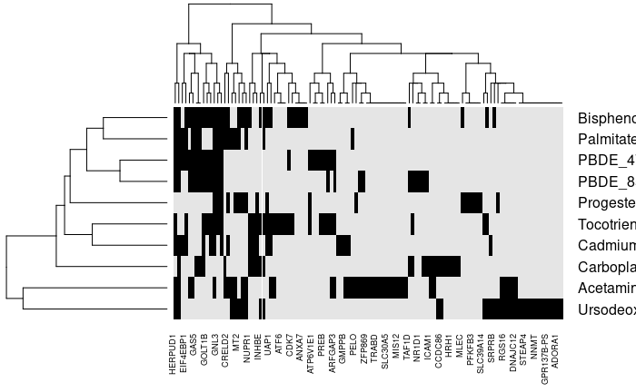

```r
gplots::heatmap.2(x=t(mx), distfun= function(c) dist(c, method="manhattan"), trace="none", key=F,
                  col=c("grey90", "black"))
```

## Reduce number of genes covered

To generate a more readable graphic select only those genes that appear at least three times.

Get counts for how often each gene was covered:

```r
gene.counts.df <- table(unlist(aggr.gene.list)) %>%
  as.data.frame(., stringsAsFactors=FALSE) %>%
  set_colnames(c("Gene", "Count")) %>%
  dplyr::arrange(desc(Count))

table(gene.counts.df$Count)
```

```
 1  2  3  4  5  6  7  8
48 26 10 12  8  2  1  3
```

```r
genes.select <- subset(gene.counts.df , Count >= 3) %>% .[,"Gene"]
cat("Number of genes selected:", length(genes.select))
```

```
Number of genes selected: 36
```

Generate new matrix:

```r
mx.select <- mx[genes.select, ]
```

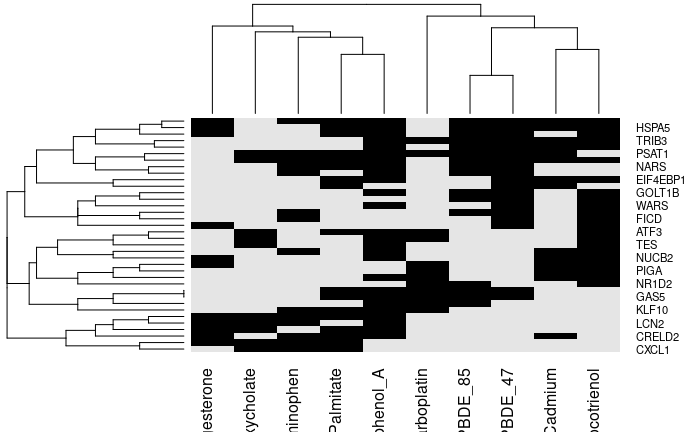

```r
plot.it <- function(mtrx) {
  gplots::heatmap.2(x=mtrx, distfun= function(c) dist(c, method="binary"), trace="none", key=F,
                  col=c("grey90", "black"))
}
plot.it(mx.select)
```

```r
pdf.file <- "Figure_S2.pdf"
pdf(file=pdf.file, paper="a4", width=7, height=10, pointsize = 6)
plot.it(mx.select)
dev.off()
```

```r
cat("File saved:", pdf.file)
```

```
File saved: Figure_S2.pdf
```

```r
rm(pdf.file)
```

## Session info

```r
cat("Date:", format(Sys.time(), "%a %d-%b-%Y %H:%M:%S"), "<br>\n")
```

Date: Mon 21-Jun-2021 08:51:29

|  | setting | value |
| --- | --- | --- |
| version | version | R version 3.6.1 (2019-07-05) |
| os | os | CentOS Linux 7 (Core) |
| system | system | x86_64, linux-gnu |
| ui | ui | RStudio |
| language | language | (EN) |
| collate | collate | en_GB.UTF-8 |
| ctype | ctype | en_GB.UTF-8 |
| tz | tz | Europe/London |
| date | date | 2021-06-21 |